# Crew survey test

## Quarto

```r
#Testing Plot combinations for plot_crew_survey
varName.options <- c(
  'port',
  'fishery',
  'demographic',
  'personal_life',
  'history',
  'employment_history',
  'employment_conditions',
  'compensation',
  'expenses',
  'satisfaction',
  'perceptions'
)
report.options <- c('MidAtlantic', 'NewEngland')
plottype.options <- c('ts', 'bar')

plot.combs <- expand.grid(
  varName = varName.options,
  report = report.options,
  plottype = plottype.options
)

devtools::load_all()
```

```
ℹ Loading ecodata
```

````r
for (i in 1:nrow(plot.combs)) {
  # plot.title <- paste(
  #   plot.combs$report[i],
  #   plot.combs$varName[i],
  #   plot.combs$plottype[i],
  #   sep = ': '
  # )

  p <- plot_crew_survey(
    report = plot.combs$report[i],
    varName = plot.combs$varName[i],
    plottype = plot.combs$plottype[i],
    n = 0
  )
title <- paste("Plot", i)
combo <- plot.combs[i,]

res <- knitr::knit_child(text = paste(
  paste("##", title),
  "This plot is showing the following parameter inputs:",
  "`r knitr::kable(combo)`",
  "Plots:",
  "```{r, echo = FALSE}",
  "print(p)",
  "```",
  "end of plot", i,
  "\n\n",
  sep = "\n\n"
),
quiet = TRUE)
cat(res, sep = "\n\n")
  # print(p)
}
````

## Plot 1

This plot is showing the following parameter inputs:

| varName | report | plottype |
| --- | --- | --- |
| port | MidAtlantic | ts |

Plots:

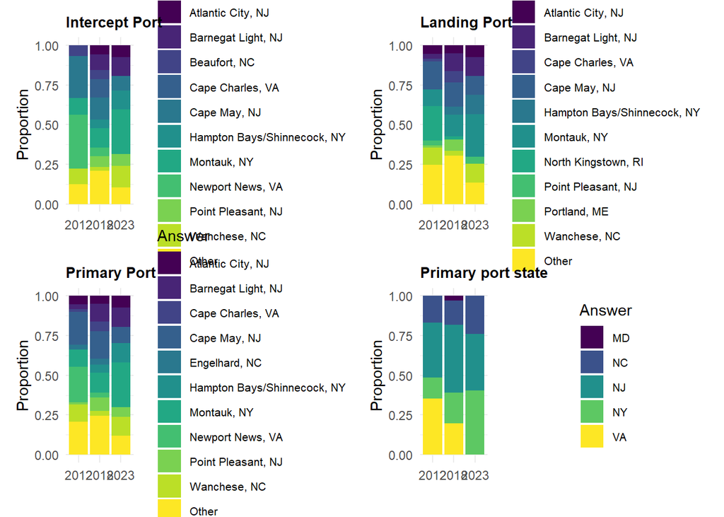

end of plot

1

## Plot 2

This plot is showing the following parameter inputs:

|  | varName | report | plottype |
| --- | --- | --- | --- |
| 2 | fishery | MidAtlantic | ts |

Plots:

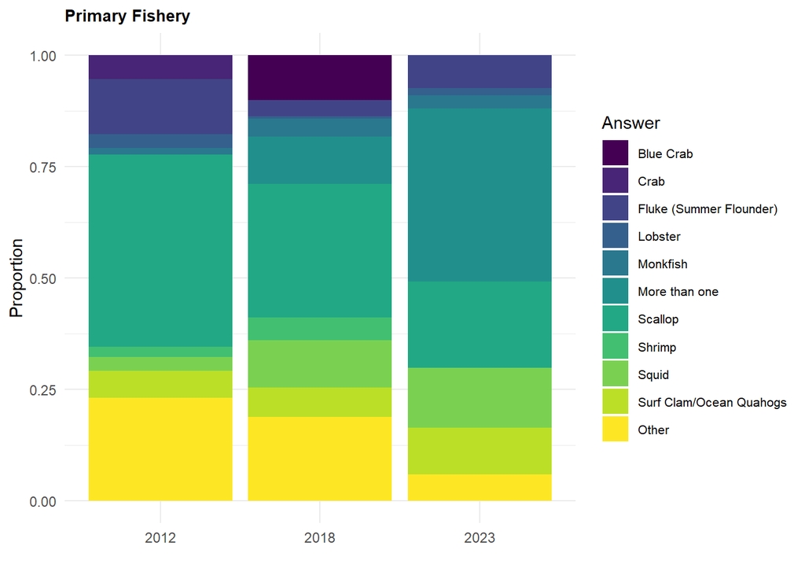

end of plot

2

## Plot 3

This plot is showing the following parameter inputs:

|  | varName | report | plottype |
| --- | --- | --- | --- |
| 3 | demographic | MidAtlantic | ts |

Plots:

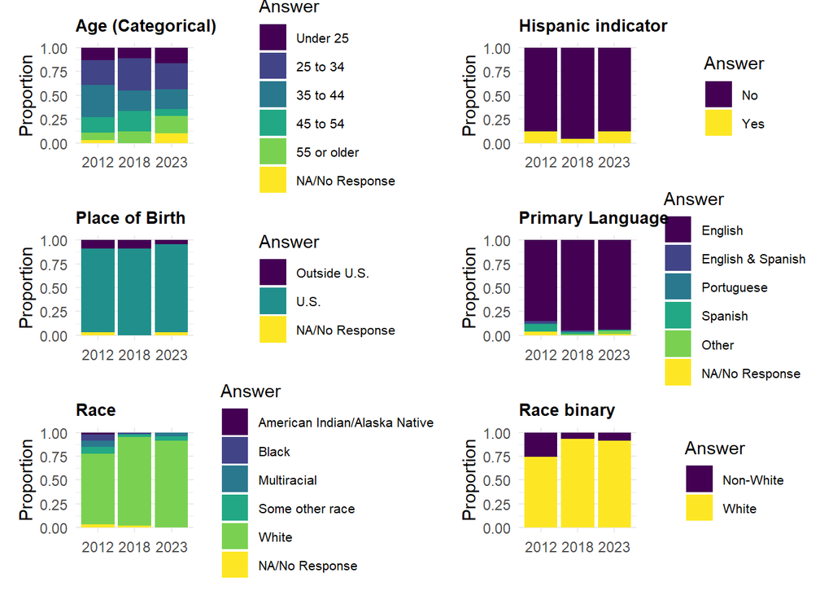

end of plot

3

## Plot 4

This plot is showing the following parameter inputs:

|  | varName | report | plottype |
| --- | --- | --- | --- |
| 4 | personal_life | MidAtlantic | ts |

Plots:

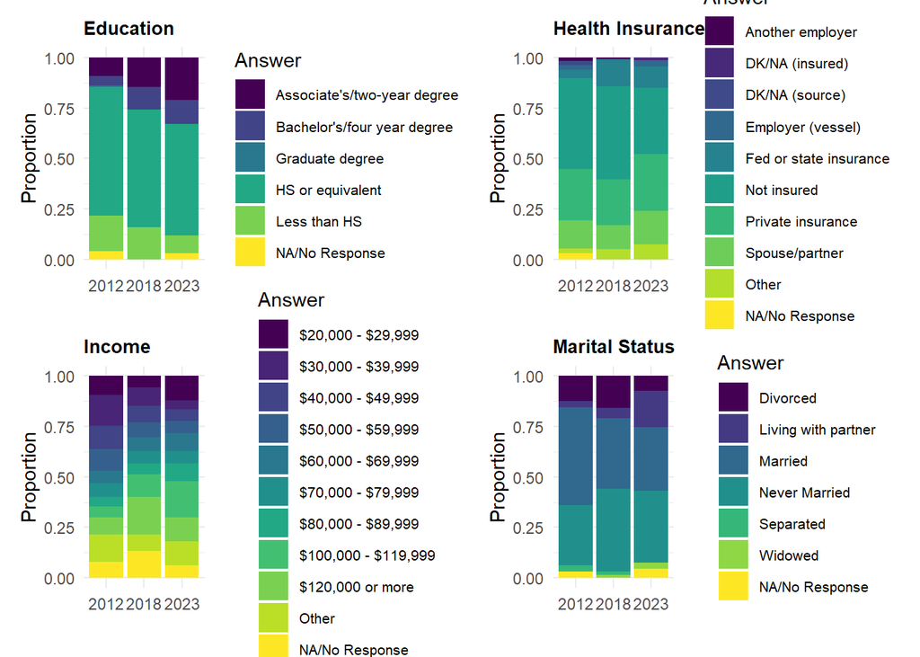

end of plot

4

## Plot 5

This plot is showing the following parameter inputs:

|  | varName | report | plottype |
| --- | --- | --- | --- |
| 5 | history | MidAtlantic | ts |

Plots:

```
N < 30
N < 30
```

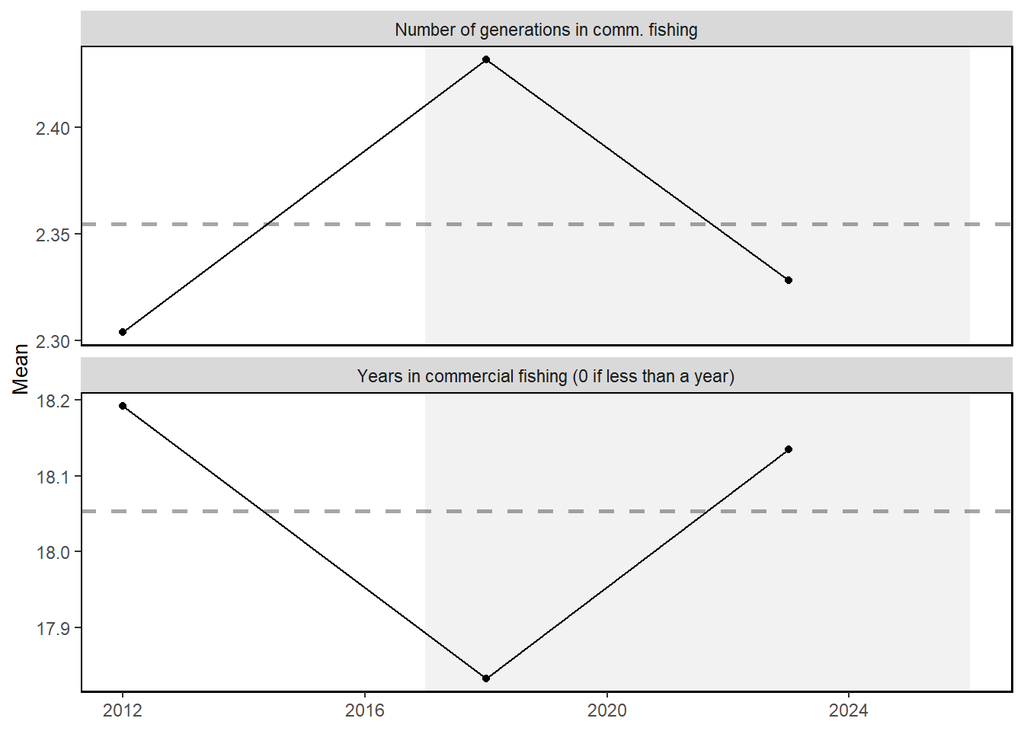

end of plot

5

## Plot 6

This plot is showing the following parameter inputs:

|  | varName | report | plottype |
| --- | --- | --- | --- |
| 6 | employment_history | MidAtlantic | ts |

Plots:

```
N < 30
N < 30
```

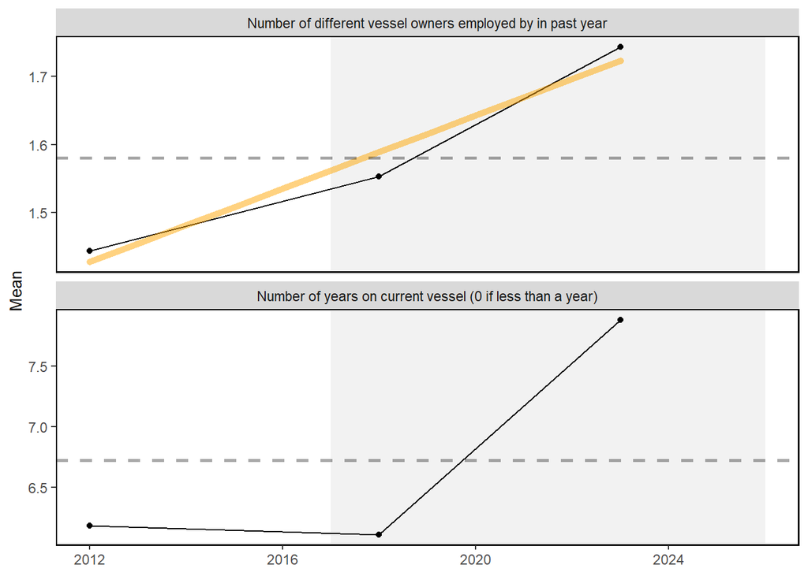

end of plot

6

## Plot 7

This plot is showing the following parameter inputs:

|  | varName | report | plottype |
| --- | --- | --- | --- |
| 7 | employment_conditions | MidAtlantic | ts |

Plots:

```
N < 30
N < 30
N < 30
N < 30
```

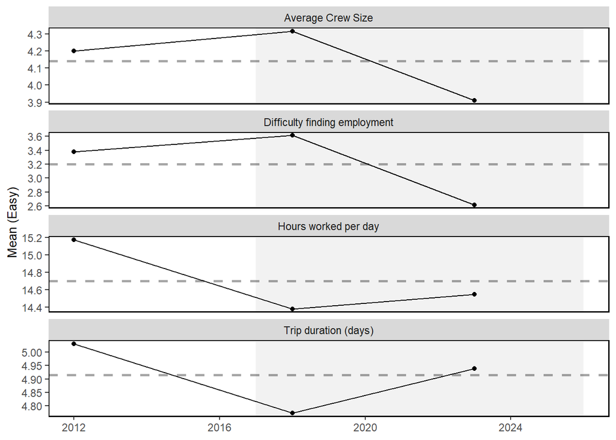

end of plot

7

## Plot 8

This plot is showing the following parameter inputs:

|  | varName | report | plottype |
| --- | --- | --- | --- |
| 8 | compensation | MidAtlantic | ts |

Plots:

```
N < 30
N < 30
```

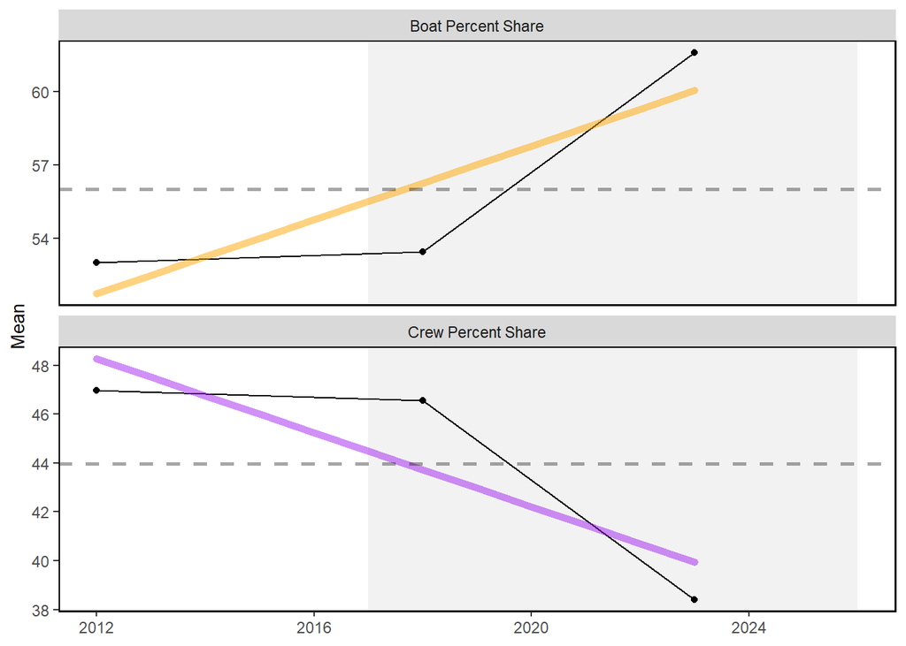

end of plot

8

## Plot 9

This plot is showing the following parameter inputs:

|  | varName | report | plottype |
| --- | --- | --- | --- |
| 9 | expenses | MidAtlantic | ts |

Plots:

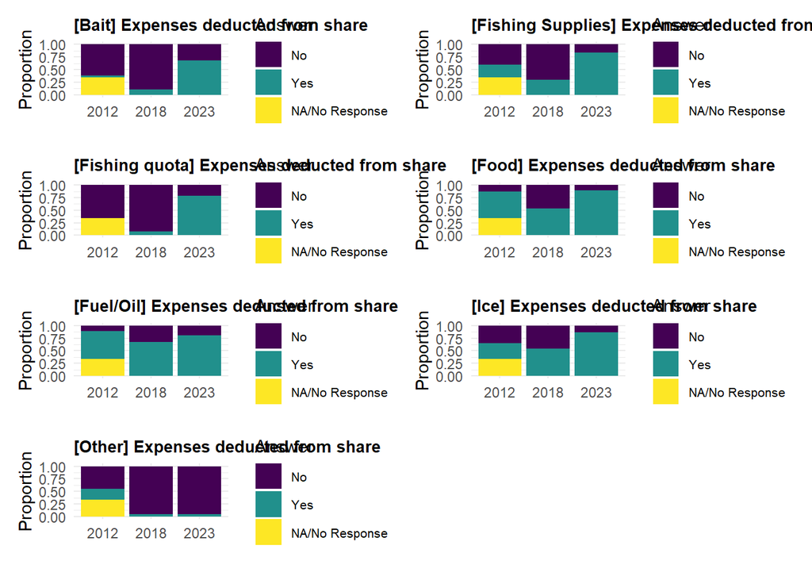

end of plot

9

## Plot 10

This plot is showing the following parameter inputs:

|  | varName | report | plottype |
| --- | --- | --- | --- |
| 10 | satisfaction | MidAtlantic | ts |

Plots:

```
N < 30
N < 30
N < 30
N < 30
N < 30
N < 30
N < 30
N < 30
N < 30
```

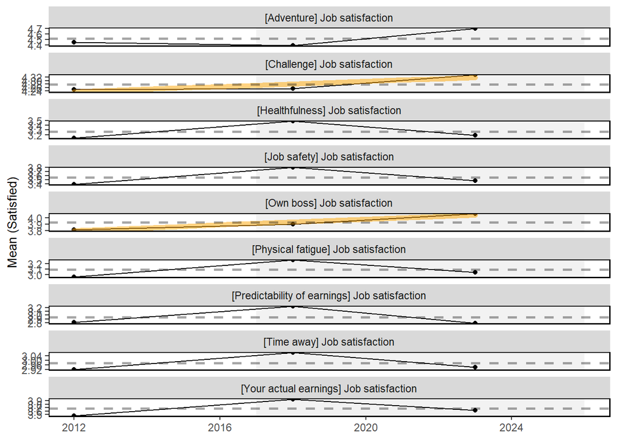

end of plot

10

## Plot 11

This plot is showing the following parameter inputs:

|  | varName | report | plottype |
| --- | --- | --- | --- |
| 11 | perceptions | MidAtlantic | ts |

Plots:

```
N < 30
N < 30
N < 30
N < 30
N < 30
```

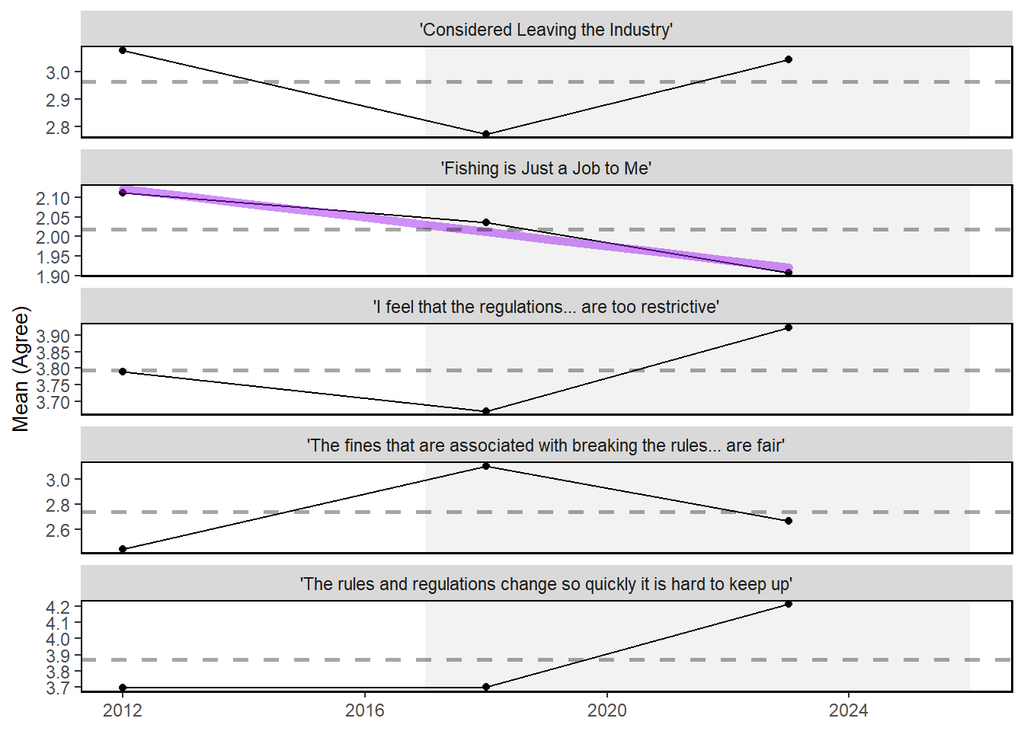

end of plot

11

## Plot 12

This plot is showing the following parameter inputs:

|  | varName | report | plottype |
| --- | --- | --- | --- |
| 12 | port | NewEngland | ts |

Plots:

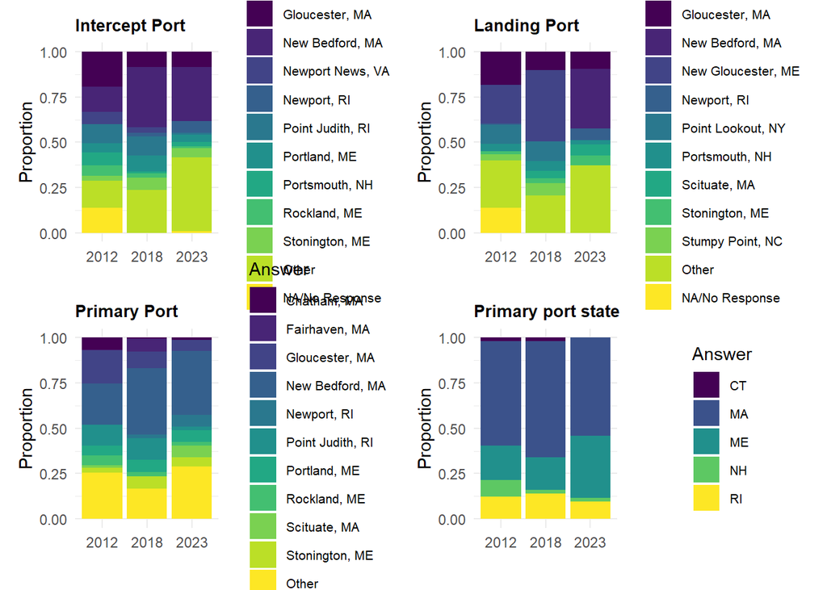

end of plot

12

## Plot 13

This plot is showing the following parameter inputs:

|  | varName | report | plottype |
| --- | --- | --- | --- |
| 13 | fishery | NewEngland | ts |

Plots:

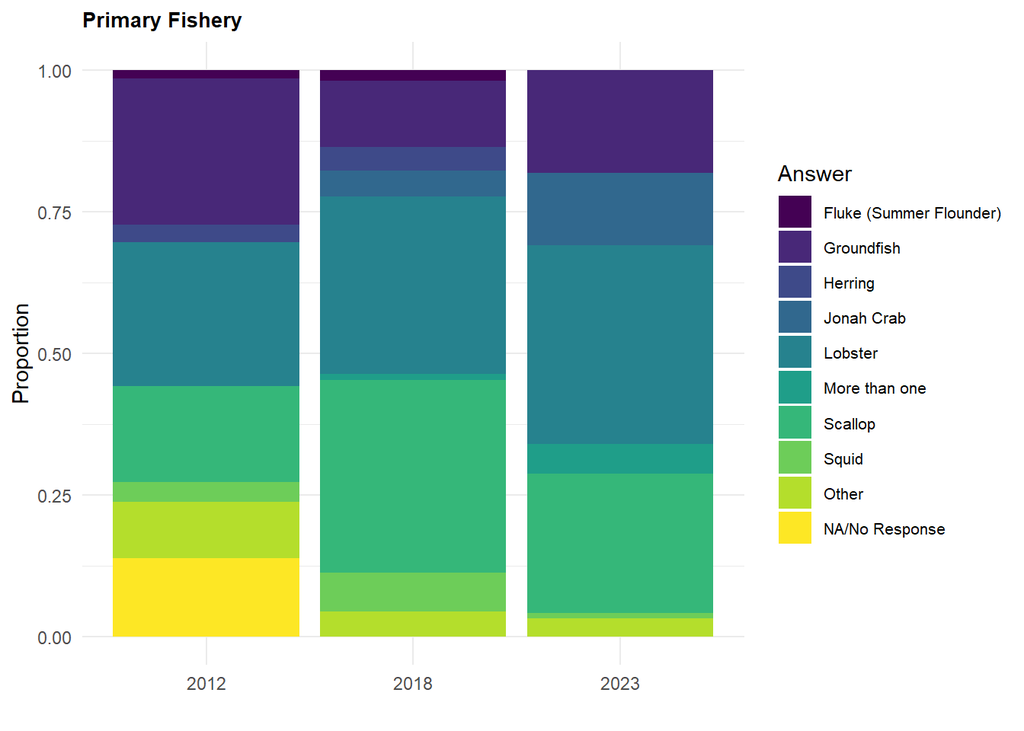

end of plot

13

## Plot 14

This plot is showing the following parameter inputs:

|  | varName | report | plottype |
| --- | --- | --- | --- |
| 14 | demographic | NewEngland | ts |

Plots:

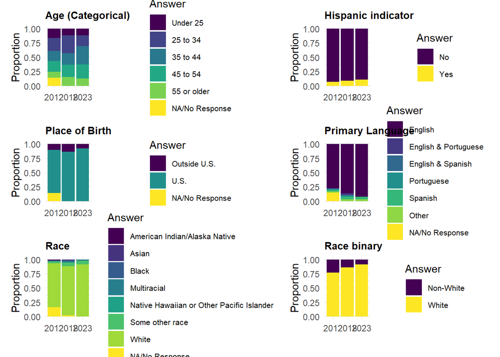

end of plot

14

## Plot 15

This plot is showing the following parameter inputs:

|  | varName | report | plottype |
| --- | --- | --- | --- |
| 15 | personal_life | NewEngland | ts |

Plots:

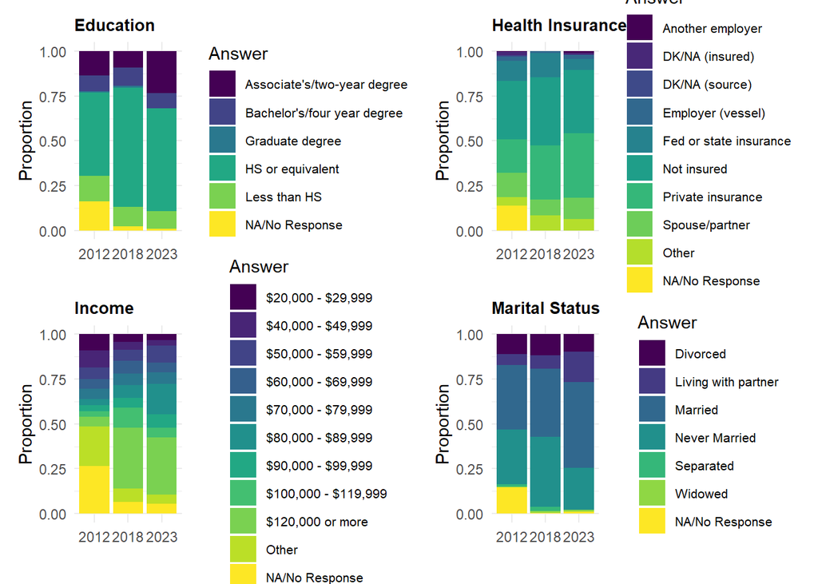

end of plot

15

## Plot 16

This plot is showing the following parameter inputs:

|  | varName | report | plottype |
| --- | --- | --- | --- |
| 16 | history | NewEngland | ts |

Plots:

```
N < 30
N < 30
```

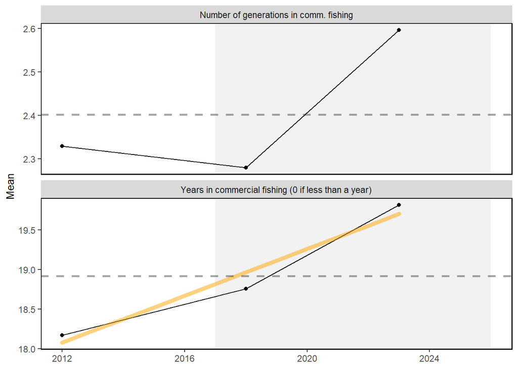

end of plot

16

## Plot 17

This plot is showing the following parameter inputs:

|  | varName | report | plottype |
| --- | --- | --- | --- |
| 17 | employment_history | NewEngland | ts |

Plots:

```
N < 30
N < 30
```

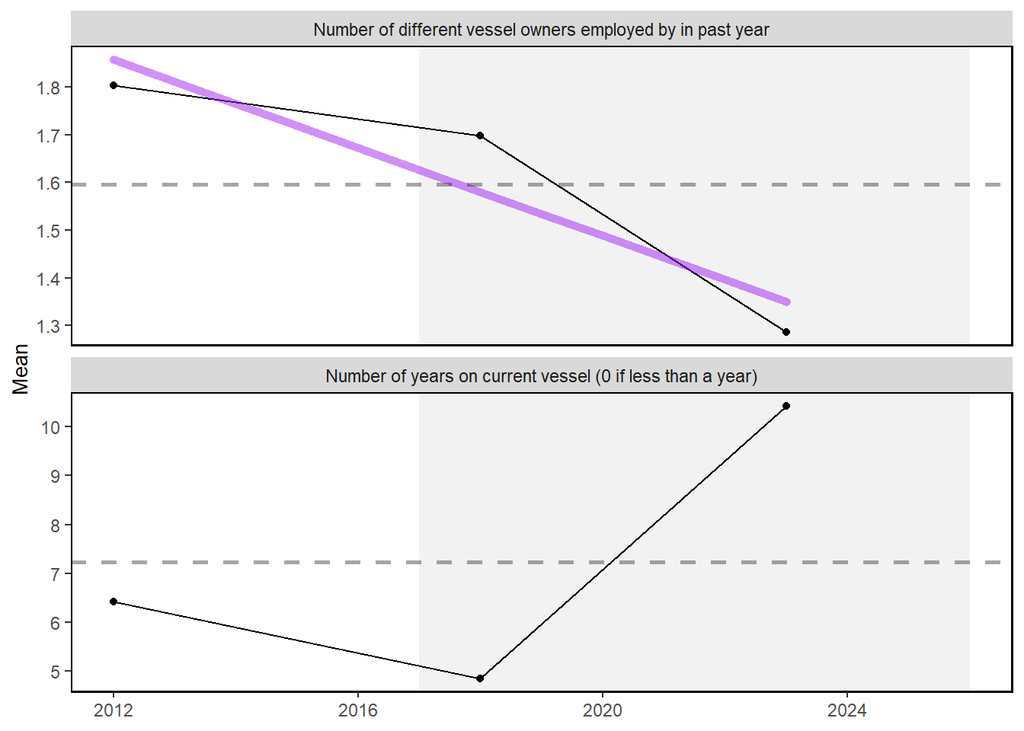

end of plot

17

## Plot 18

This plot is showing the following parameter inputs:

|  | varName | report | plottype |
| --- | --- | --- | --- |
| 18 | employment_conditions | NewEngland | ts |

Plots:

```
N < 30
N < 30
N < 30
N < 30
```

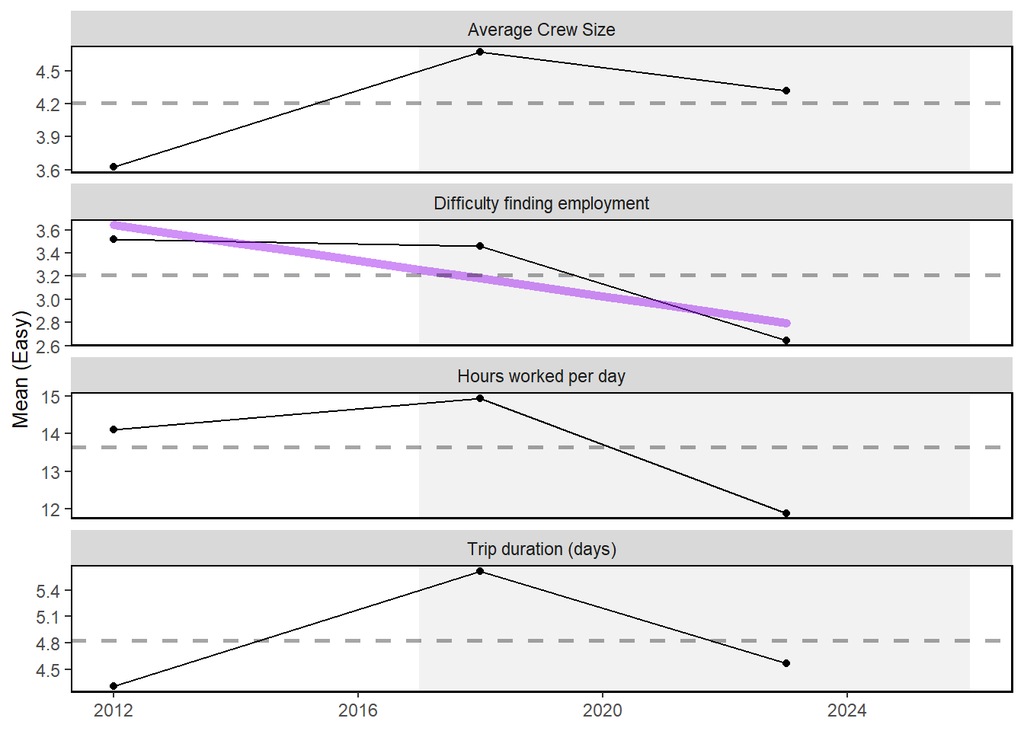

end of plot

18

## Plot 19

This plot is showing the following parameter inputs:

|  | varName | report | plottype |
| --- | --- | --- | --- |
| 19 | compensation | NewEngland | ts |

Plots:

```
N < 30
N < 30
```

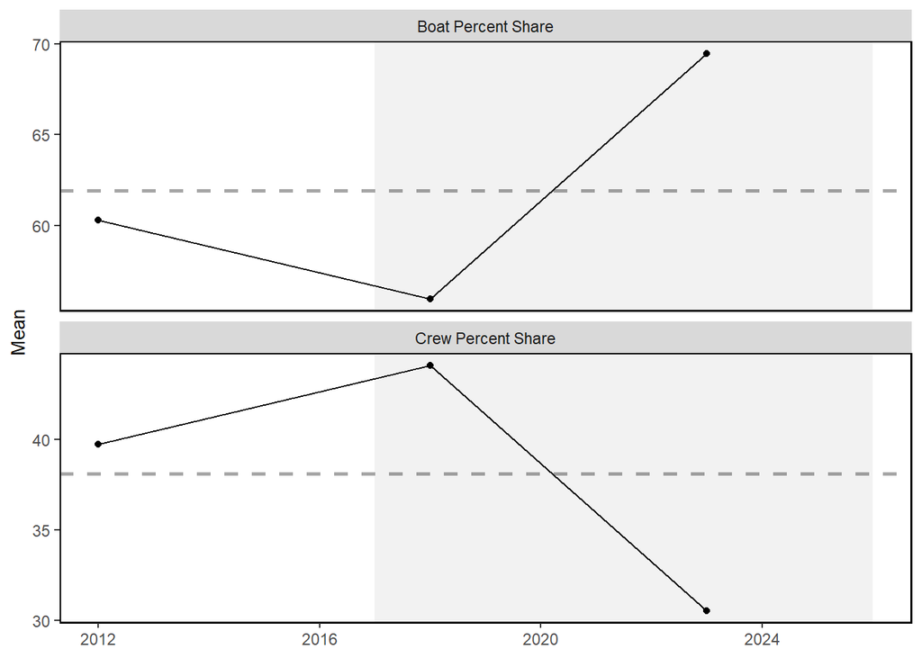

end of plot

19

## Plot 20

This plot is showing the following parameter inputs:

|  | varName | report | plottype |
| --- | --- | --- | --- |
| 20 | expenses | NewEngland | ts |

Plots:

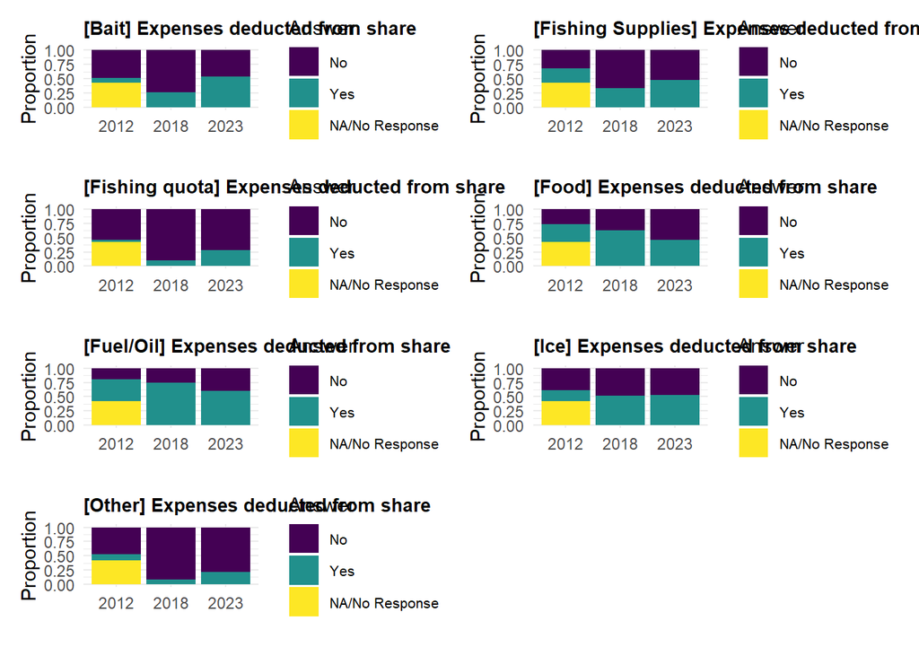

end of plot

20

## Plot 21

This plot is showing the following parameter inputs:

|  | varName | report | plottype |
| --- | --- | --- | --- |
| 21 | satisfaction | NewEngland | ts |

Plots:

```
N < 30
N < 30
N < 30
N < 30
N < 30
N < 30
N < 30
N < 30
N < 30
```

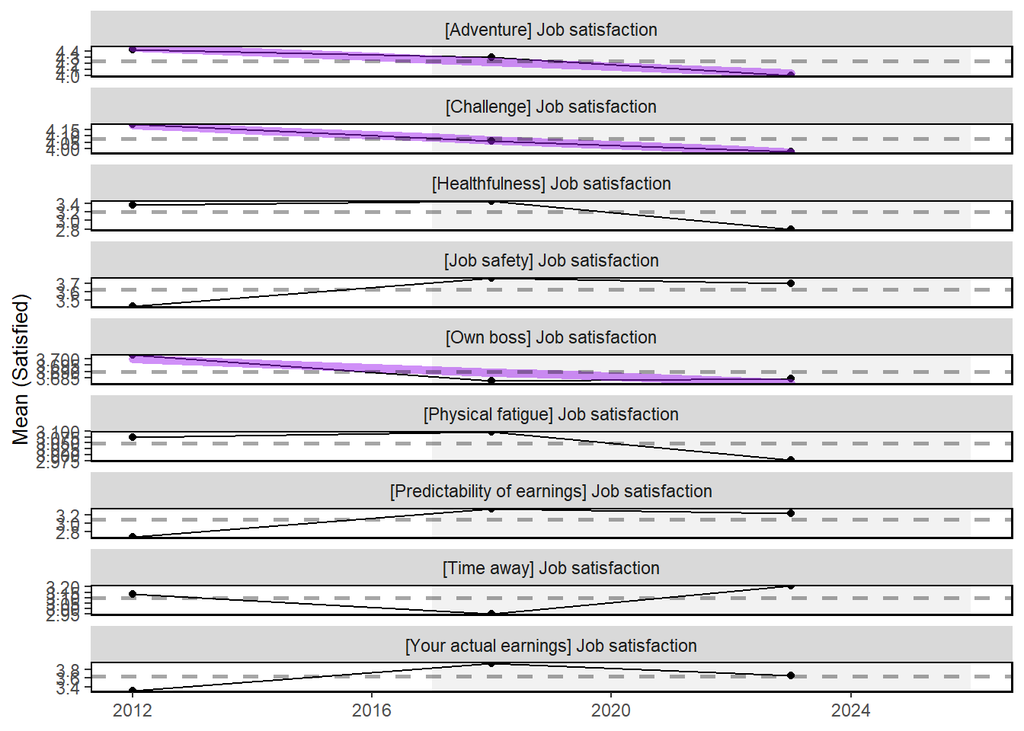

end of plot

21

## Plot 22

This plot is showing the following parameter inputs:

|  | varName | report | plottype |
| --- | --- | --- | --- |
| 22 | perceptions | NewEngland | ts |

Plots:

```
N < 30
N < 30
N < 30
N < 30
N < 30
```

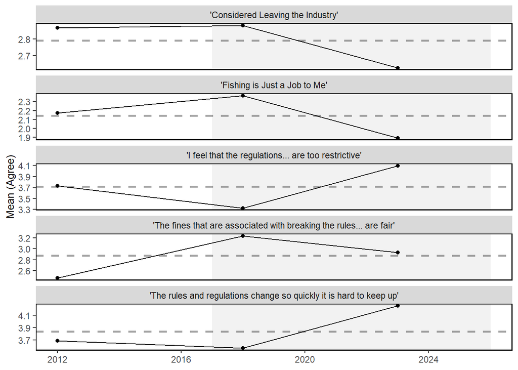

end of plot

22

## Plot 23

This plot is showing the following parameter inputs:

|  | varName | report | plottype |
| --- | --- | --- | --- |
| 23 | port | MidAtlantic | bar |

Plots:

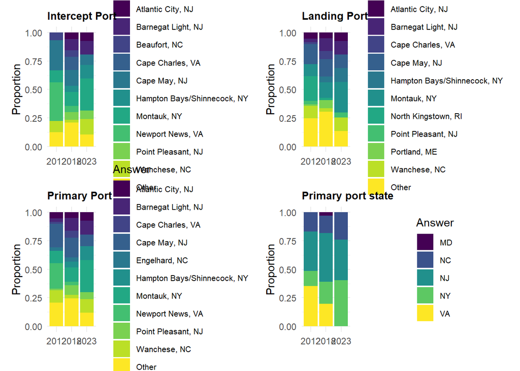

end of plot

23

## Plot 24

This plot is showing the following parameter inputs:

|  | varName | report | plottype |
| --- | --- | --- | --- |
| 24 | fishery | MidAtlantic | bar |

Plots:

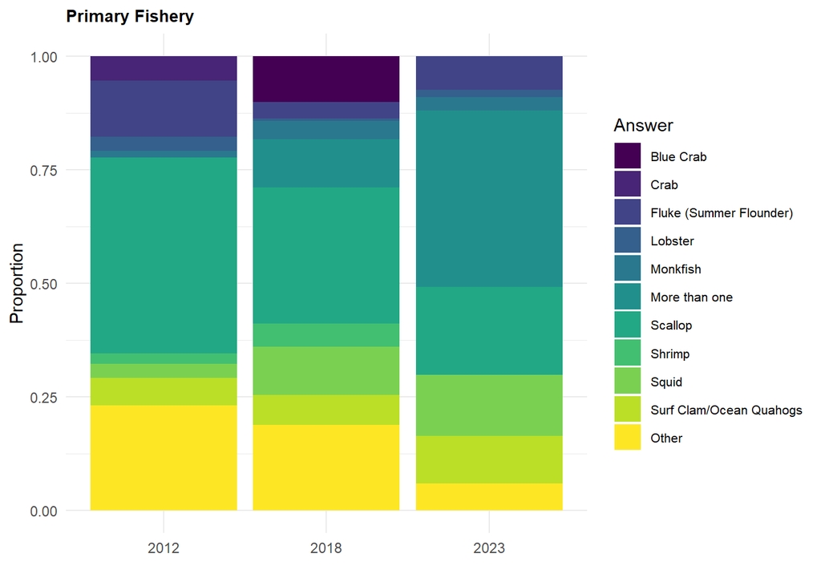

end of plot

24

## Plot 25

This plot is showing the following parameter inputs:

|  | varName | report | plottype |
| --- | --- | --- | --- |
| 25 | demographic | MidAtlantic | bar |

Plots:

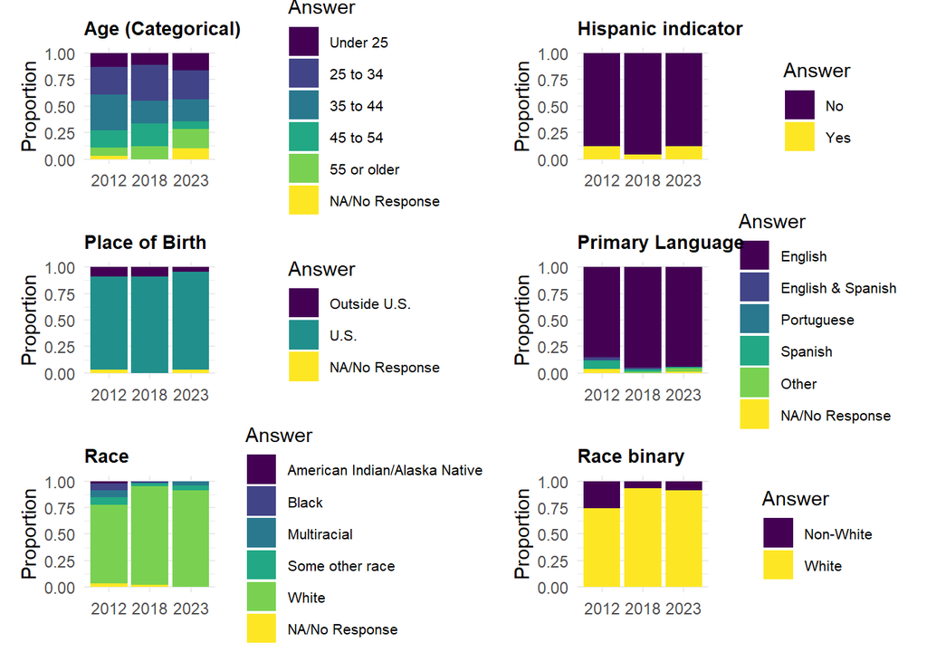

end of plot

25

## Plot 26

This plot is showing the following parameter inputs:

|  | varName | report | plottype |
| --- | --- | --- | --- |
| 26 | personal_life | MidAtlantic | bar |

Plots:

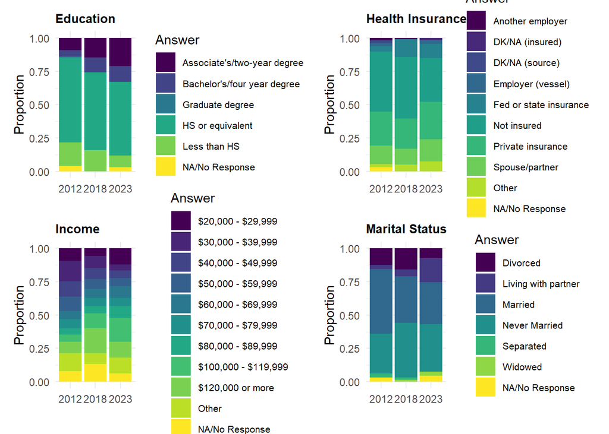

end of plot

26

## Plot 27

This plot is showing the following parameter inputs:

|  | varName | report | plottype |
| --- | --- | --- | --- |
| 27 | history | MidAtlantic | bar |

Plots:

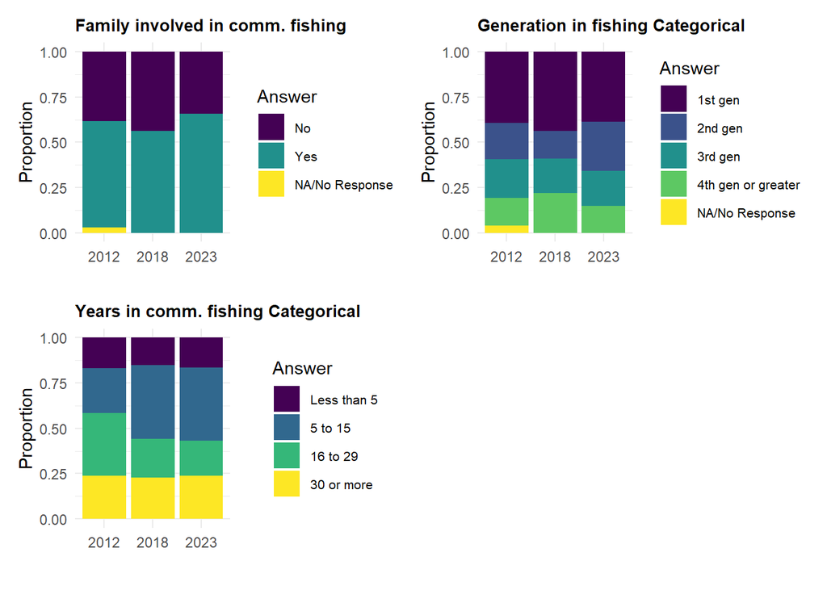

end of plot

27

## Plot 28

This plot is showing the following parameter inputs:

|  | varName | report | plottype |
| --- | --- | --- | --- |
| 28 | employment_history | MidAtlantic | bar |

Plots:

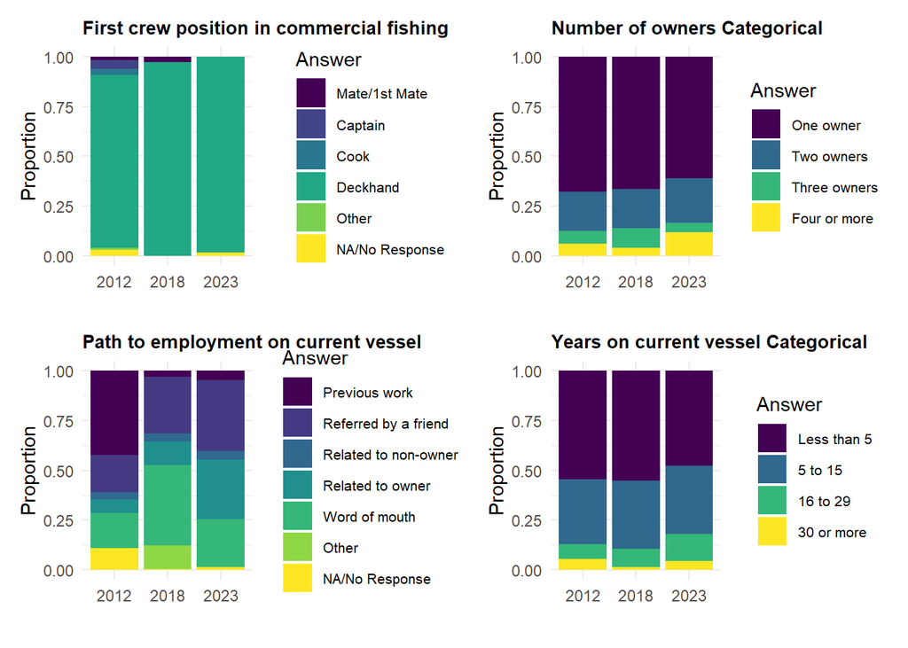

end of plot

28

## Plot 29

This plot is showing the following parameter inputs:

|  | varName | report | plottype |
| --- | --- | --- | --- |
| 29 | employment_conditions | MidAtlantic | bar |

Plots:

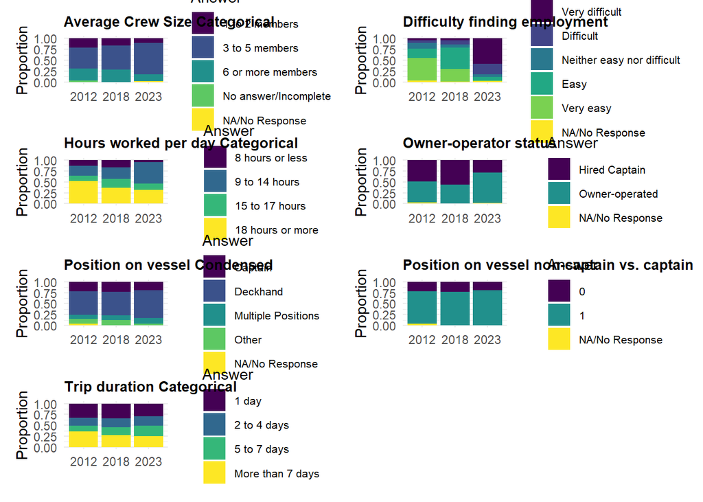

end of plot

29

## Plot 30

This plot is showing the following parameter inputs:

|  | varName | report | plottype |
| --- | --- | --- | --- |
| 30 | compensation | MidAtlantic | bar |

Plots:

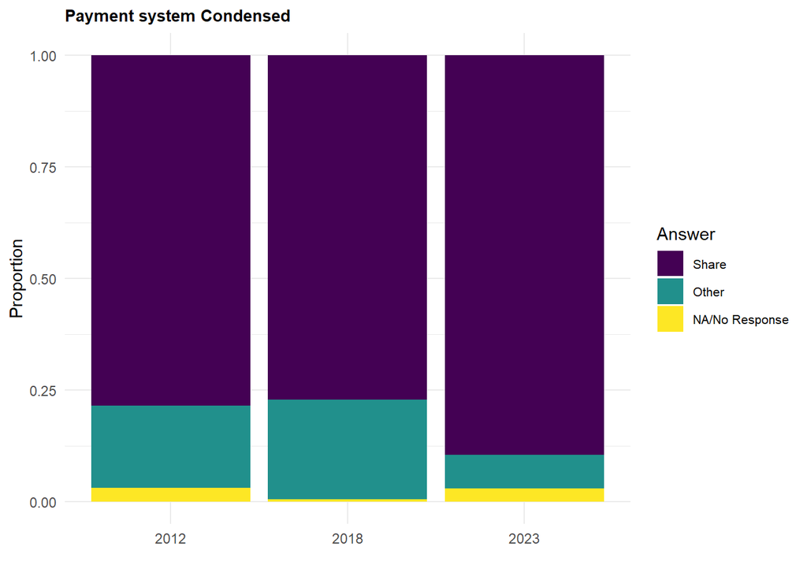

end of plot

30

## Plot 31

This plot is showing the following parameter inputs:

|  | varName | report | plottype |
| --- | --- | --- | --- |
| 31 | expenses | MidAtlantic | bar |

Plots:

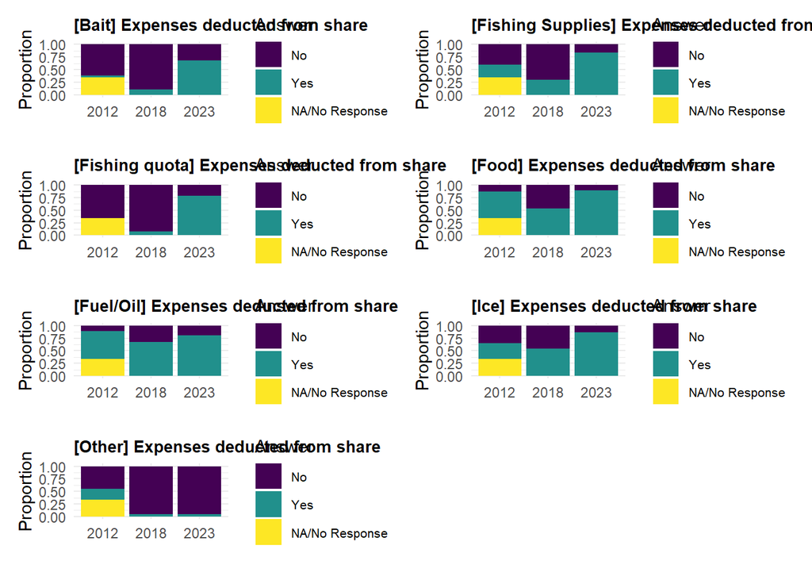

end of plot

31

## Plot 32

This plot is showing the following parameter inputs:

|  | varName | report | plottype |
| --- | --- | --- | --- |
| 32 | satisfaction | MidAtlantic | bar |

Plots:

[figure not shown]

end of plot

32

## Plot 33

This plot is showing the following parameter inputs:

|  | varName | report | plottype |
| --- | --- | --- | --- |
| 33 | perceptions | MidAtlantic | bar |

Plots:

[figure not shown]

end of plot

33

## Plot 34

This plot is showing the following parameter inputs:

|  | varName | report | plottype |
| --- | --- | --- | --- |
| 34 | port | NewEngland | bar |

Plots:

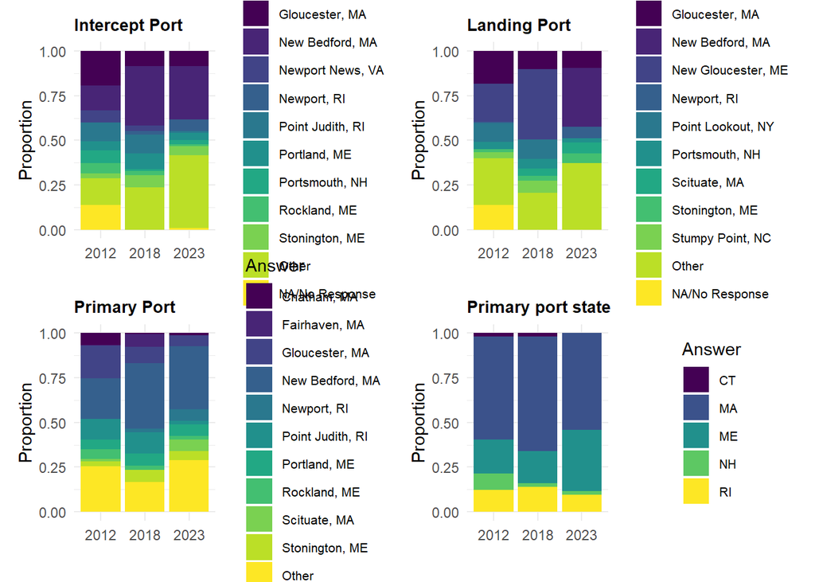

end of plot

34

## Plot 35

This plot is showing the following parameter inputs:

|  | varName | report | plottype |
| --- | --- | --- | --- |
| 35 | fishery | NewEngland | bar |

Plots:

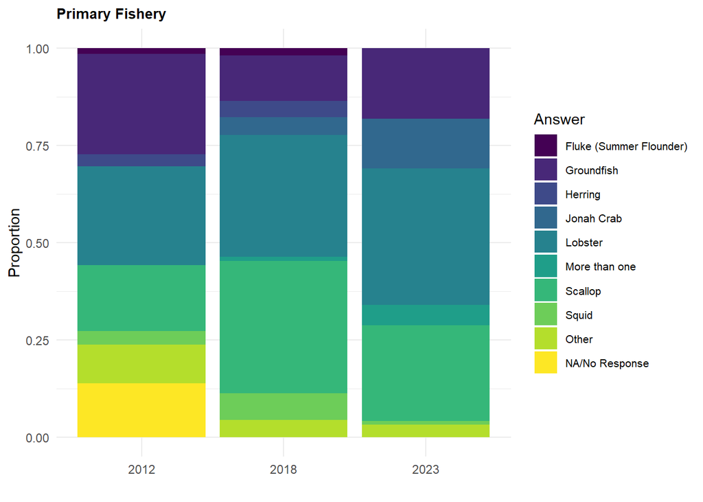

end of plot

35

## Plot 36

This plot is showing the following parameter inputs:

|  | varName | report | plottype |
| --- | --- | --- | --- |
| 36 | demographic | NewEngland | bar |

Plots:

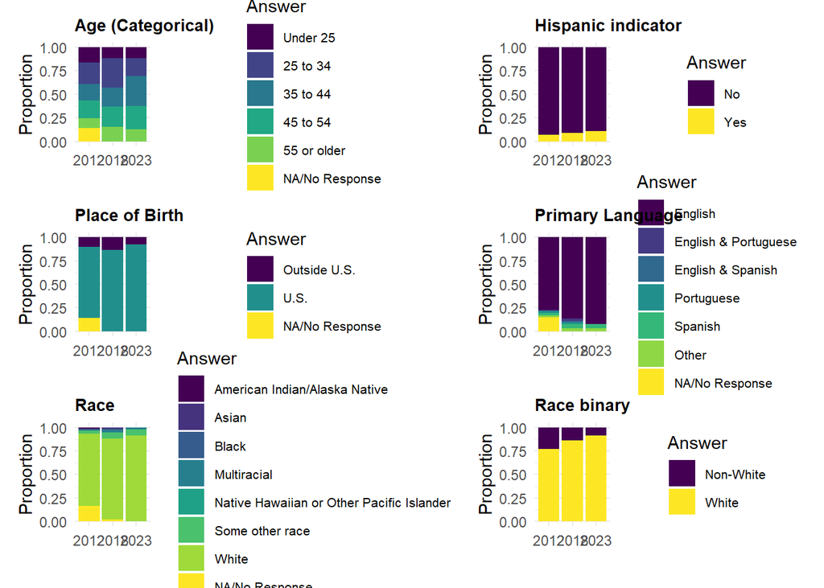

end of plot

36

## Plot 37

This plot is showing the following parameter inputs:

|  | varName | report | plottype |
| --- | --- | --- | --- |
| 37 | personal_life | NewEngland | bar |

Plots:

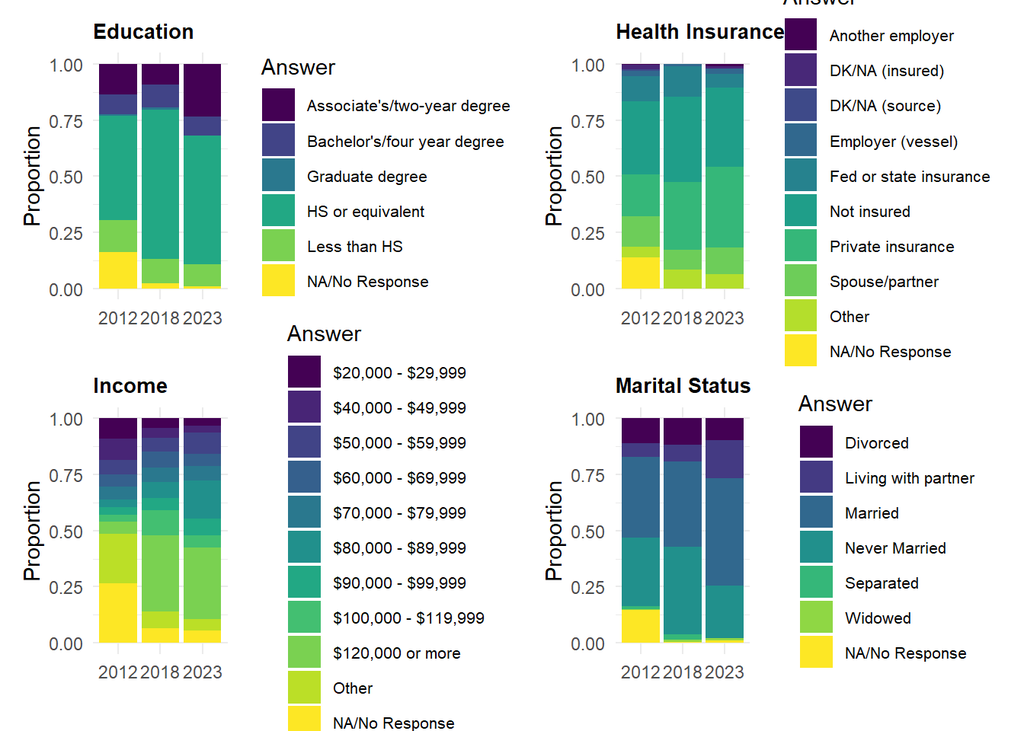

end of plot

37

## Plot 38

This plot is showing the following parameter inputs:

|  | varName | report | plottype |
| --- | --- | --- | --- |
| 38 | history | NewEngland | bar |

Plots:

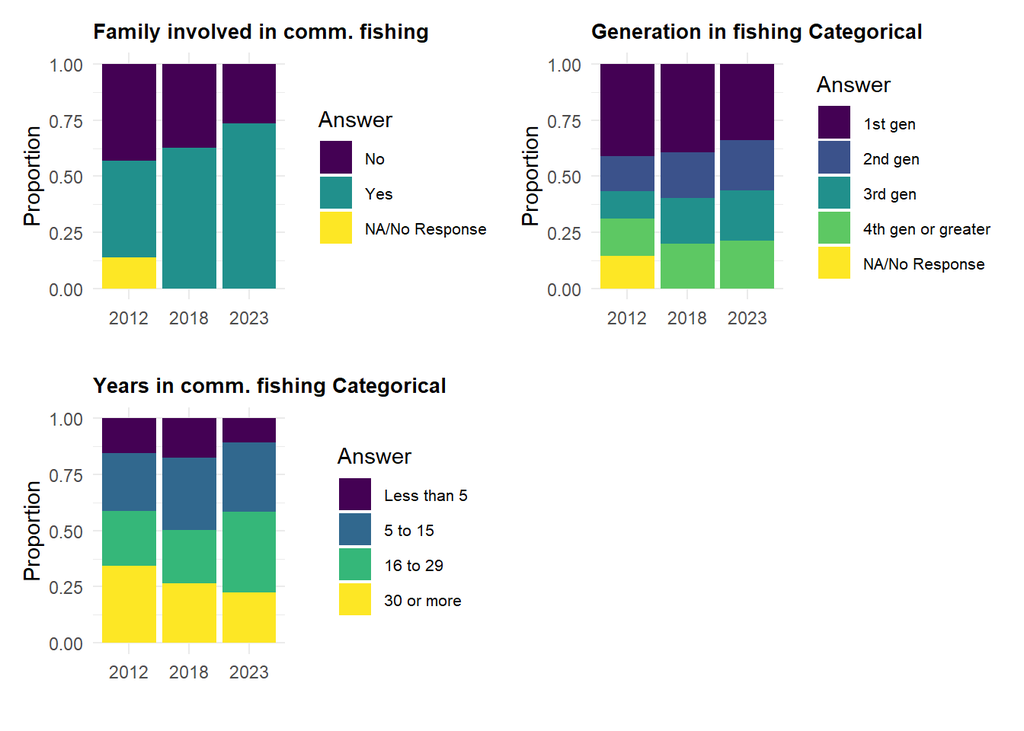

end of plot

38

## Plot 39

This plot is showing the following parameter inputs:

|  | varName | report | plottype |
| --- | --- | --- | --- |
| 39 | employment_history | NewEngland | bar |

Plots:

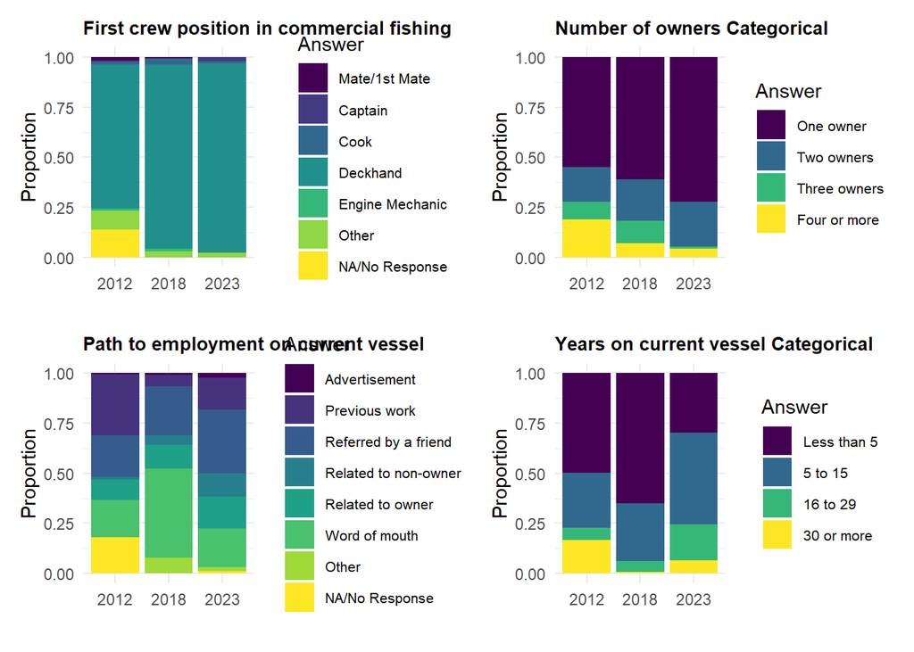

end of plot

39

## Plot 40

This plot is showing the following parameter inputs:

|  | varName | report | plottype |
| --- | --- | --- | --- |
| 40 | employment_conditions | NewEngland | bar |

Plots:

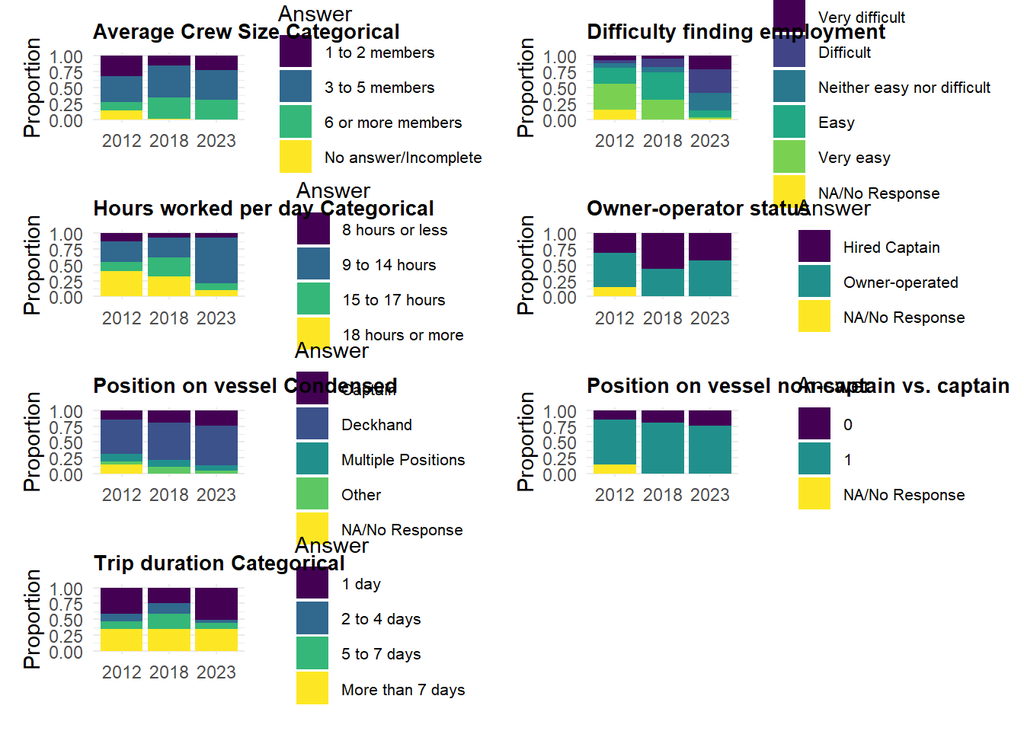

end of plot

40

## Plot 41

This plot is showing the following parameter inputs:

|  | varName | report | plottype |
| --- | --- | --- | --- |
| 41 | compensation | NewEngland | bar |

Plots:

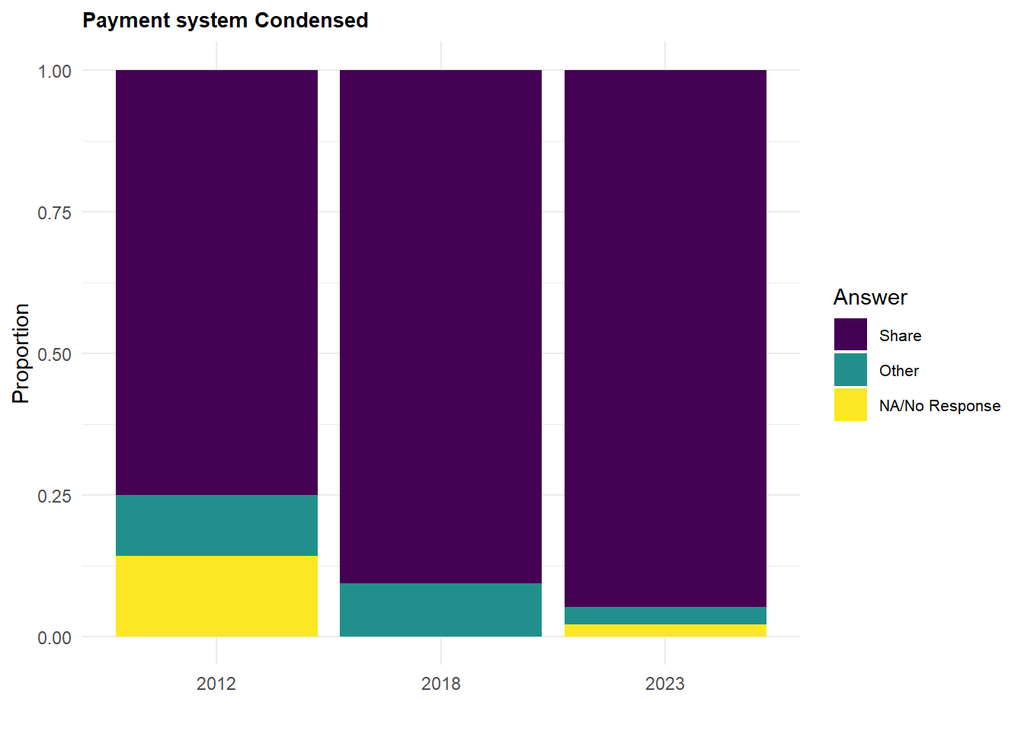

end of plot

41

## Plot 42

This plot is showing the following parameter inputs:

|  | varName | report | plottype |
| --- | --- | --- | --- |
| 42 | expenses | NewEngland | bar |

Plots:

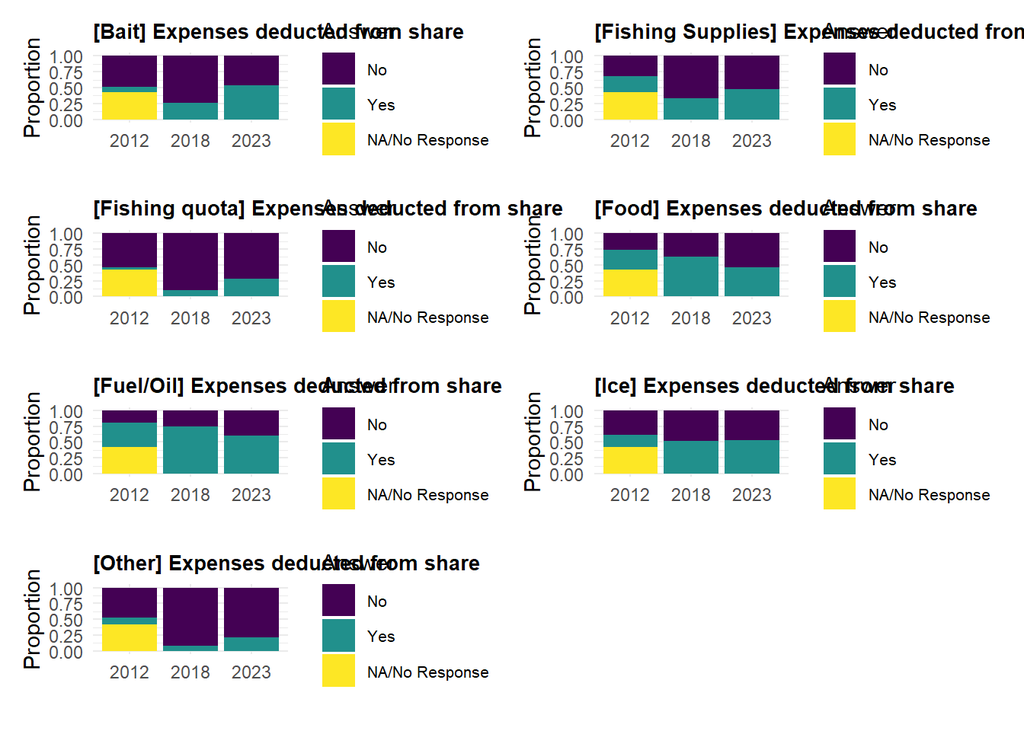

end of plot

42

## Plot 43

This plot is showing the following parameter inputs:

|  | varName | report | plottype |
| --- | --- | --- | --- |
| 43 | satisfaction | NewEngland | bar |

Plots:

[figure not shown]

end of plot

43

## Plot 44

This plot is showing the following parameter inputs:

|  | varName | report | plottype |
| --- | --- | --- | --- |
| 44 | perceptions | NewEngland | bar |

Plots:

[figure not shown]

end of plot

44